# Introduction to StatComp

Heng Tang

2019-01-11

## Question

Write a .Rmd file to implement at least three examples of diffrernt types in the above books

## Answer

### Example1

```r
x=1:30
y=matrix(x,nrow=6)
y
```

```
##      [,1] [,2] [,3] [,4] [,5]
## [1,]    1    7   13   19   25
## [2,]    2    8   14   20   26
## [3,]    3    9   15   21   27
## [4,]    4   10   16   22   28
## [5,]    5   11   17   23   29
## [6,]    6   12   18   24   30
```

### Example2

```r
m=seq(1,5.5,0.5)
l=matrix(m,nrow=2)
colnames(l)=c("a","b","c","d","e")
knitr::kable(l)
```

| a | b | c | d | e |
| --- | --- | --- | --- | --- |
| 1.0 | 2.0 | 3.0 | 4.0 | 5.0 |
| 1.5 | 2.5 | 3.5 | 4.5 | 5.5 |

### Example3

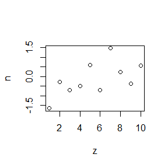

```r
n=rnorm(10)
z=1:10
plot(n~z)
```

## Question

Exercises 3.5,3.7 and 3.12

## Answer

### question 3.5

#### idea:

x is a discrete distribution function,so we can use the inverse transform $F_{x}^{-1}\left ( u \right )= x_{i}$ for $F_{x}\left ( x_{i-1} \right )< u\leq F_{x}\left ( x_{i} \right )$.Then we generate $U\sim U\left ( 0,1 \right )$.So we can get the empirical probabilities.At last,I construct a matrix to show the difference between the empirical with the theoretical probabilities.

#### answer

```
##                                x=0   x=1   x=2   x=3   x=4
## the empirical distribution   0.106 0.193 0.228 0.197 0.276
## the theoretical distribution 0.100 0.200 0.200 0.200 0.300
## the rate                     1.060 0.965 1.140 0.985 0.920
```

#### R code

```r
x=c(0,1,2,3,4)
p=c(0.1,0.2,0.2,0.2,0.3)
cp=cumsum(p)
 m <- 1e3
r=numeric(m)
r <- x[findInterval(runif(m),cp)+1]
ct <- as.vector(table(r))
t=ct/sum(ct)
q=ct/sum(ct)/p
k=rbind(t,p,q)
colnames(k)=c("x=0","x=1","x=2","x=3","x=4")
rownames(k)=c("the empirical distribution","the theoretical distribution","the rate")
k
```

### question 3.7

#### idea:

Beta(a,b)=$\int_{0}^{1}x^{a-1}(1-x)^{b-1}$,so the distribution function of beta(a,b) is $f\left ( x \right )= \frac{a(a+b-1)}{b-1}x^{a-1}\left ( 1-x \right )^{b-1}$,we can let $g\left ( x \right )= x$,$0< x< 1$,and $c=\frac{a(a+b-1)}{b-1}$.Then we use the acceptance-rejection method,generate random numbers $U\sim U\left ( 0,1 \right )$ and $Y\sim g\left ( \right )$.We can create the function to generate a random sample of size n from the Beta(a,b) distribution.Then make a=3,b=2,n=1000.

#### answer

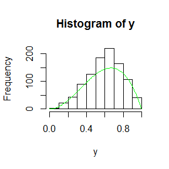

#### R code

```r
f<-function(a,b,n){
  j=w=0
  y=numeric(n)
  while(w<n){
    u <- runif(1)
    j <- j + 1
    x1 <- runif(1)
    if (x1^(a-1) * (1-x1)^(b-1) > u) {
      w <- w + 1
      y[w] <- x1
    }
  }
  y
}
y=f(3,2,1000)
hist(y)
curve(dbeta(x,3,2)*1000/12,add=T,col="green")
```

### question 3.12

#### idea:

we know r=4 and $\beta = 2$,so We can bring the parameters into the distribution function.Get the distribution function of y about r and $\beta$.At last,we generate 1000 random observations from this mixture.

#### answer

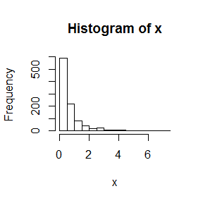

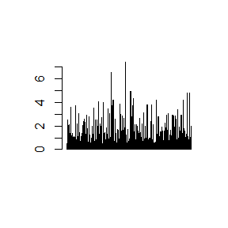

#### R code

```r
n=1000
r=4
beta1=2
t=rgamma(n,r,beta1)
x=rexp(n,t)
hist(x)
barplot(x)
```

## Question

Exercises 5.4, 5.9, 5.13, and 5.14

## Answer

### question 5.4

Write a function to compute a Monte Carlo estimate of the Beta(3, 3) cdf, and use the function to estimate F(x) forx =0.1,0.2,…,0.9. Compare the estimates with the values returned by the pbeta function in R.

#### idea:

First,we know the Beta(3,3) distribution function is $F(x)=\int^{x}_{0}\frac{1}{B(3,3)}t^{2}(1-t)^{2}\,dt$.From the page,we know if a and b are ???nite, then$\int_{a}^{b}h\left ( x \right )dx=\int_{a}^{b}g\left ( x \right )\frac{1}{b-a}dx=E\left [ g\left ( X \right ) \right ]$,where $X\sim U\left ( 0,1 \right )$,$g\left ( x \right )=(b-a)h(x)$.Use a frequency to approximation the expectation (Strong Law of Large Number):$\frac{1}{m}\sum_{i=1}^{m}g(X_{i})$.

#### answer:

|  | 0.1 | 0.2 | 0.3 | 0.4 | 0.5 | 0.6 | 0.7 | 0.8 | 0.9 |
| --- | --- | --- | --- | --- | --- | --- | --- | --- | --- |
| MC | 0.0082812 | 0.0572861 | 0.1599577 | 0.3161491 | 0.4985758 | 0.6813681 | 0.8415916 | 0.9448613 | 0.9909419 |
| pBeta | 0.0085600 | 0.0579200 | 0.1630800 | 0.3174400 | 0.5000000 | 0.6825600 | 0.8369200 | 0.9420800 | 0.9914400 |

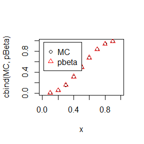

#### R code

```r
 f=function(x){
  m=10000
  t=runif(m,min=0,max=x)
  th=mean(1/beta(3,3)*t^(2)*(1-t)^(2)*x)
}
x=seq(0.1,0.9,by=0.1)
MC=numeric(9)
for(i in 1:9){
  result=f(x[i])
  MC[i]=result[[1]]
}
pBeta=pbeta(x,3,3)
m=rbind(MC,pBeta)
knitr::kable(m,col.names=x)
```

### question 5.9

The Rayleigh density [156, (18.76)] is $f(x)=\frac{x}{\sigma^2}e^{-x^2/(2\sigma^2)},x\ge0,\sigma>0$. Implement a function to generate samples from a Rayleigh($\sigma$) distribution, using antithetic variables. What is the percent reduction in variance of $\frac{X+X'}{2}$ compared with $\frac{X_1+X_2}{2}$ for independent $X_1,X_2$?

#### idea:

We can calculate the cumulative distribution function of this function $F(x)=1-e^{-\frac{x^2}{2\sigma^2}}$.Because $x\ge0$,so we need use the inverse distribution.It is easy to get the inverse distribution $X=F^-(U)=\sqrt{-2\sigma^2\ln(1-U)},U\sim U(0,1)$.Then we use the antithetic variables to generate samples.g1 represents $\frac{X+X'}{2}$,g2 represents $\frac{X_1+X_2}{2}$ .

#### answer:

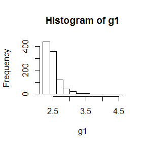

```
##        sd(g1)        sd(g2) sd(g1)/sd(g2)
##     0.2292178     0.8959220     0.2558457
```

#### R code

```r
f1=function(n,sigma){
  x1=runif(n/2)
  x2=1-x1
  x=c(x1,x2)
  y=sqrt(-2*sigma^2*log(1-x))
  return(y)
}
f2=function(n,sigma){
  x=runif(n)
  y=sqrt(-2*sigma^2*log(1-x))
  return(y)
}
n=10000
g1=f1(n,2)
g2=f2(n,2)
hist(g1)
qqplot(g1,g2)
z=c(sd(g1),sd(g2),sd(g1)/sd(g2))
names(z)=c("sd(g1)","sd(g2)","sd(g1)/sd(g2)")
z
```

### question 5.13

Find two importance functions $f1$ and $f2$ that are supported on $(1, ∞)$ and are ‘close’ to $g(x) = \frac{x^2}{\sqrt{2\pi}} e^{-{x^2}/2}, x > 1$. Which of your two importance functions should produce the smaller variance in estimating $\int_1^\infty\frac{x^2}{\sqrt{2\pi}} e^{-{x^2}/2}\,dx$ by importance sampling? Explain.

### answer:

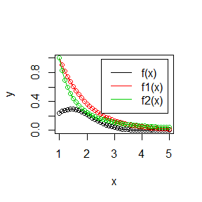

```
##                 f1          f2
## theta 0.3945716577 0.383107827
## sd    0.0001583718 0.000306109
```

```
## [1] "s1<s2,so f1 is better than f2"
```

#### R code

```r
n=1000
f=function(x){
  x^2/sqrt(2*pi)*exp(-(x^2)/2)
}
f1=function(x){
  exp(-x+1)
}
f2=function(x){
   1/x^2
}
x=seq(1,5,0.1)
plot(x,f(x),col=1,type="o",ylim=c(0,1),lty=1,ylab="y")
points(x,f1(x),col=2,type="o",lty=1)
lines(x,f2(x),col=3,type="o",lty=1)
legend("topright",inset=.05,legend=c("f(x)","f1(x)","f2(x)"),lty=1,col=1:3,horiz=FALSE)
  X1=rexp(n,rate=1)+1
  theta1=mean(f(X1)/f1(X1))
  sd1=sd(f(X1)/f1(X1))/n
  X2=runif(n)
  X2<-1/(1-X2)
  theta2=mean(f(X2)/f2(X2))
  sd2=sd(f(X2)/f2(X2))/n
  a=c(theta1,sd1,theta2,sd2)
  a=matrix(a,nrow=2)
  colnames(a)=c("f1","f2")
  rownames(a)=c("theta","sd")
  a
```

### question 5.14

Obtain a Monte Carlo estimate of $\int_1^\infty\frac{x^2}{\sqrt{2\pi}} e^{-{x^2}/2}\,dx$ by importance sampling.

#### idea:

We can use the importance function $f1$ to obtain a Monte Carlo estimate.

#### answer

```
##                 f1
## theta 0.4148616871
## sd    0.0001520442
```

#### R code

```r
n=1000
f=function(x){
  x^2/sqrt(2*pi)*exp(-(x^2)/2)
}
f1=function(x){
  exp(-x+1)
}
  X1=rexp(n,rate=1)+1
  theta1=mean(f(X1)/f1(X1))
  sd1=sd(f(X1)/f1(X1))/n
  a=c(theta1,sd1)
  a=matrix(a,ncol=1)
  colnames(a)=c("f1")
  rownames(a)=c("theta","sd")
  a
```

## Question Exercises 6.9, 6.10, and 6.B

## Answer

### question 6.9

Let $X$ be a non-negative random variable with $\mu=E[x]<\infty$. For a random sample $x_1,\ldots,x_n$ from the distribution of $X$, the Gini ratio is defined by
$$G=\frac1{2n^2\mu} \sum_{j=1}^n\sum_{i=1}^n |x_i-x_j|.$$
The Gini ratio is applied in economics to measure inequality in income distribution (see e.g. [163]). Note that G can be written in terms of the order statistics $x_{(i)}$ as
$$G=\frac1{n^2\mu}\sum_{i=1}^n (2i-n-1)x_{(i)}.$$
If the mean is unknown,let $\hat{G}$ be the statistic $G$ with $\mu$ replaced by $\bar{x}$. Estimate by simulation the mean, median and deciles of $\hat{G}$ if $X$ is standard lognormal. Repeat the procedure for the uniform distribution and Bernoulli(0.1). Also construct density histograms of the replicates in each case.

#### idea:

First,we can constract a function to estimate if there comes a sample.Then we can estimate if X is standard lognormal. Repeat the procedure for the uniform distribution and Bernoulli(0.1).At last,we plot the image.

#### answer:

```
##      mean    median   deciles
## 0.5191125 0.5191102 0.4953675
```

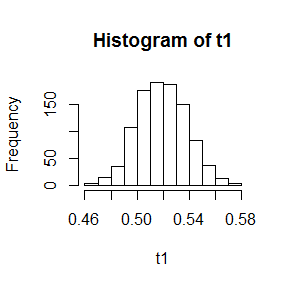

```
##      mean    median   deciles
## 0.3331752 0.3327079 0.3194290
```

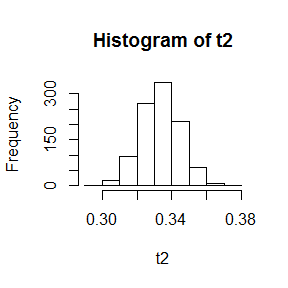

```
##    mean  median deciles
##  0.8998  0.9000  0.8820
```

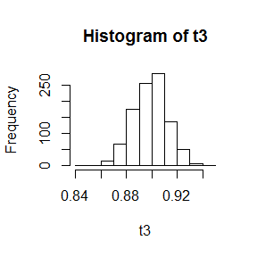

#### R code

```r
f<-function(x){
  n<-length(x)
  a<-seq(1-n,n-1,2)
  i<-sort(x)
  y<-sum(a*i)/(n*n*mean(x))
  return(y)
}
n=500
m<-1000
t1<-numeric(m)
for(i in 1:m){
  q<-rnorm(n)
  p<-exp(q)
  t1[i]<-f(p)
}
result1<-c(mean(t1),quantile(t1,probs=c(0.5,0.1)))
names(result1)<-c("mean","median","deciles")
print(result1)
hist(t1)
t2<-numeric(m)
for(i in 1:m){
  x<-runif(n) # then x is uniform
  t2[i]<-f(x)
}
result2<-c(mean(t2),quantile(t2,probs=c(0.5,0.1)))
names(result2)<-c("mean","median","deciles")
print(result2)
hist(t2)
t3<-numeric(m)
for(i in 1:m){
  x<-rbinom(n,1,0.1) # then x is Bernoulli(0.1)
  t3[i]<-f(x)
}
result3<-c(mean(t3),quantile(t3,probs=c(0.5,0.1)))
names(result3)<-c("mean","median","deciles")
print(result3)
hist(t3)
```

### question 6.10

Construct an approximate 95% confidence intervalfor the Gini ratio $\gamma=E[G]$ if $X$ is lognormal with unknown parameters. Assess the coverage rate of the estimation procedure with a Monte Carlo experiment.

#### idea:

Because X is lognormal with unknown parameters.So we can use $\hat\gamma=\bar{G},\hat\sigma_G=\frac{1}{m-1}\sum_{i=1}^{m}(G_i-\bar{G})^2$ .Then can get the approximate 95% confidence intervalfor.

#### answer:

```
## [1] 0.4814230 0.5572252
```

```
## [1] 0.954
```

#### R code

```r
n=500
m=1000
G1<-function(n){
  y<-rnorm(n,1,1)
  x<-exp(y)
  G.sample<-f(x)
  return(G.sample)
}
G.sp<-numeric(m)
for(i in 1:m){
  G.sp[i]<-G1(n,1,1)
}
CI<-c(mean(G.sp)-sd(G.sp)*qt(0.975,m-1),mean(G.sp)+sd(G.sp)*qt(0.975,m-1))
print(CI)
cover.rate<-sum(I(G.sp>CI[1]&G.sp<CI[2]))/m
print(cover.rate)
```

### question 6.B

Tests for association based on Pearson product moment correlation $\rho$, Spearman’s rank correlation coe???cient $\rho_{s}$ or Kendall’s coefficient $\tau$, are implemented in cor.test. Show (empirically) that the nonparametric tests based on $\rho_s$ or$\tau$ are less powerful than the correlation test when the sampled distribution is bivariate normal. Find an example of an alternative (a bivariate distribution (X,Y) such that X and Y are dependent) such that at least one of the nonparametric tests have better empirical power than the correlation test against this alternative.

#### answer

| method | power |
| --- | --- |
| pearson | 0.6088 |
| kendall | 0.5646 |
| spearman | 0.5738 |

#### R code

```r
library(mvtnorm)
power.test<-function(method,cor){
  n1<-500
  n2<-1e4
  mean<-c(0,0)
  sigma<-matrix(c(1,cor,cor,1),nrow=2)
  p<-mean(replicate(n2,expr={
    x<-rmvnorm(n1,mean,sigma)
    cor.test(x[,1],x[,2],method=method)$p.value<=0.05
  }))
  p
}
power<-data.frame(method=c("pearson","kendall","spearman"),power=c(power.test("pearson",0.1),power.test("kendall",0.1),power.test("spearman",0.1)))
knitr::kable(power,format="markdown",align="c")
```

## Question Exercises 7.1, 7.5, 7.8, and 7.11

## Answer

### question 7.1

Compute a jackknife estimate of the bias and the standard error of the correlation statistic in Example 7.2.

#### idea:

First,we use a matrix to read the data.As a function of x1,…,xn, the estimate $\hat{\theta }$ can be written as $\hat{\theta }\left ( x_{1},x_{2},...,x_{n} \right )$.An unbiased estimate of the bias $E\left ( \hat{\theta } \right )-\theta _{0}$ is $\left ( n-1 \right )\left (\bar{\hat{\theta }} _{\left ( . \right )}-\hat{\theta } \right )$.An unbiased estimate of $se\left ( \hat{\theta } \right )$ is $\sqrt{\frac{n-1}{n}\sum_{i-1}^{n}(\hat{\theta _{(i)}}-\bar{\hat{\theta _{(\cdot )}}})^{2}}$.Then,we can bring data into the formula.

#### answer:

```
## original     bias       se
##    0.776   -0.006    0.143
```

#### R code

```r
c1=c(576,635,558,578,666,580,555,661,651,605,653,575,545,572,594)
c2=c(339,330,281,303,344,307,300,343,336,313,312,274,276,288,296)
x=matrix(c(c1,c2),ncol=2)
b.cor <- function(x,i) cor(x[i,1],x[i,2])
n <- 15
theta.hat <- b.cor(x,1:n)
theta.jack <- numeric(n)
for(i in 1:n){
  theta.jack[i] <- b.cor(x,(1:n)[-i])
}
bias.jack <- (n-1)*(mean(theta.jack)-theta.hat)
se.jack <- sqrt((n-1)*mean((theta.jack-theta.hat)^2))
round(c(original=theta.hat,bias=bias.jack, se=se.jack),3)
```

### question 7.5

7.5 Refer to Exercise 7.4. Compute 95% bootstrap confidence intervals for the mean time between failures $1/ \lambda$ by the standard normal, basic, percentile, and BCa methods. Compare the intervals and explain why they may differ.

#### idea:

we can use the function boot to get the 95% bootstrap confidence intervals.we can find the basic intervals is the samllest,the BCa is the biggest.

#### answer:

```
##    hours
## 1      3
## 2      5
## 3      7
## 4     18
## 5     43
## 6     85
## 7     91
## 8     98
## 9    100
## 10   130
## 11   230
## 12   487
```

```
##
## ORDINARY NONPARAMETRIC BOOTSTRAP
##
##
## Call:
## boot(data = aircondit$hours, statistic = b.mean, R = 1000)
##
##
## Bootstrap Statistics :
##     original     bias    std. error
## t1* 108.0833 -0.5736667    37.19356
```

```
## BOOTSTRAP CONFIDENCE INTERVAL CALCULATIONS
## Based on 1000 bootstrap replicates
##
## CALL :
## boot.ci(boot.out = mean.boot, type = c("norm", "basic", "perc",
##     "bca"))
##
## Intervals :
## Level      Normal              Basic
## 95%   ( 35.8, 181.6 )   ( 27.0, 170.3 )
##
## Level     Percentile            BCa
## 95%   ( 45.8, 189.2 )   ( 56.6, 222.9 )
## Calculations and Intervals on Original Scale
## Some BCa intervals may be unstable
```

#### R code

```r
library(boot)
aircondit
b.mean=function(x,i)mean(x[i])
mean.boot=boot(data=aircondit$hours,statistic=b.mean,R=1000)
mean.boot
CI=boot.ci(mean.boot,type=c("norm","basic","perc","bca"))
CI
```

### question 7.8

Refer to Exercise 7.7. Obtain the jackknife estimates of bias and standard error of $\hat{\theta}$.

#### idea:

First,we get the cov of the scor.then we get the cov of every row.We can use the formula to get the bias.jack and se.jack.

#### answer:

```
##    mec vec alg ana sta
## 1   77  82  67  67  81
## 2   63  78  80  70  81
## 3   75  73  71  66  81
## 4   55  72  63  70  68
## 5   63  63  65  70  63
## 6   53  61  72  64  73
## 7   51  67  65  65  68
## 8   59  70  68  62  56
## 9   62  60  58  62  70
## 10  64  72  60  62  45
## 11  52  64  60  63  54
## 12  55  67  59  62  44
## 13  50  50  64  55  63
## 14  65  63  58  56  37
```

[output cut: 74 more lines]

```
## [1] 0.001069139
```

```
## [1] 0.04955231
```

#### R code

```r
library(bootstrap)
scor
n=nrow(scor)
sigma.hat=cov(scor)*(n-1)/n
eigenvalues.hat=eigen(sigma.hat)$values
theta.hat=eigenvalues.hat[1]/sum(eigenvalues.hat)
theta.jack=numeric(n)
for(i in 1:n){
  sigma.jack=cov(scor[-i,])*(n-1)/n
  eigenvalues.jack=eigen(sigma.jack)$values
  theta.jack[i]=eigenvalues.jack[1]/sum(eigenvalues.jack)
}
bias.jack=(n-1)*(mean(theta.jack)-theta.hat)
bias.jack
se.jack=sd(theta.jack)*sqrt((n-1)^2/n)
se.jack
```

### question 7.11

In Example 7.18, leave-one-out (n-fold) cross validation was used to select the best fitting model. Use leave-two-out cross validation to compare the models.

#### answer:

```
## [1] 19.57227 17.87018 18.45491 14.12271
```

#### R code

```r
library(DAAG)
attach(ironslag)
n <- length(magnetic)
e1 <- e2 <- e3 <- e4 <- cbind(rep(0,n*(n-1)/2),rep(0,n*(n-1)/2))
k=1
for(i in 1:(n-1)){
  for(j in (i+1):n ){
    y <- magnetic[-c(i,j)]
    x <- chemical[-c(i,j)]
    J1 <- lm(y ~ x)
    yhat11 <- J1$coef[1] + J1$coef[2] * chemical[i]
    yhat12 <- J1$coef[1] + J1$coef[2] * chemical[j]
    e1[k,1]=yhat11-magnetic[i]
    e1[k,2]=yhat12-magnetic[j]

    J2 <- lm(y ~ x + I(x^2))
    yhat21 <- J2$coef[1] + J2$coef[2] * chemical[i] +J2$coef[3] * chemical[i]^2
    yhat22 <- J2$coef[1] + J2$coef[2] * chemical[j] +J2$coef[3] * chemical[j]^2
    e2[k,1]=yhat21-magnetic[i]
    e2[k,2]=yhat22-magnetic[j]
    J3 <- lm(log(y) ~ x)
    logyhat31 <- J3$coef[1] + J3$coef[2] * chemical[i]
    yhat31 <- exp(logyhat31)
    logyhat32 <- J3$coef[1] + J3$coef[2] * chemical[j]
    yhat32 <- exp(logyhat32)
    e3[k,1] <-  yhat31-magnetic[i]
    e3[k,2] <-  yhat32-magnetic[j]
    J4 <- lm(log(y) ~ log(x))
    logyhat41 <- J4$coef[1] + J4$coef[2] * log(chemical[i])
    logyhat42 <- J4$coef[1] + J4$coef[2] * log(chemical[j])
    yhat41 <- exp(logyhat41)
    yhat42 <- exp(logyhat42)
    e4[k,1] <-  yhat41 -magnetic[i]
    e4[k,1] <-  yhat42 -magnetic[j]
    k=k+1
  }
}

c(mean(e1^2), mean(e2^2), mean(e3^2), mean(e4^2))
```

## Question

Exercises 8.1 Exercises 9.3 Exercises 9.6

## Answer

### question 8.1

Implement the two-sample Cramer-von Mises test for equal distributions as a permutation test. Apply the test to the data in Examples 8.1 and 8.2.

#### idea:

First,we use to function to achieve the two-sample Cramer-von Mises test for equal distributions.Then we use the function the test the data.

#### answer:

```
## [1] 0.3976024
```

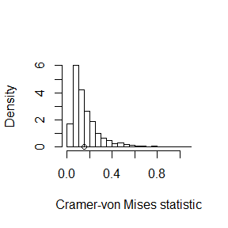

#### R code

```r
f <- function(x1,x2){
  Fx1<-ecdf(x1)
  Fx2<-ecdf(x2)
  n<-length(x1)
  m<-length(x2)
  w1<-sum((Fx1(x1)-Fx2(x1))^2)+sum((Fx1(x2)-Fx2(x2))^2)
  w2<-w1*m*n/((m+n)^2)
  return(w2)
}
attach(chickwts)
x <- sort(as.vector(weight[feed == "soybean"]))
y <- sort(as.vector(weight[feed == "linseed"]))
detach(chickwts)
t=f(x,y)
m=c(x,y)
z <- numeric(1000)
m1=length(m)
m2=length(x)
q=1:m1
for (i in 1:1000) {
  d= sample(q, size = m2, replace = FALSE)
  q1 <- m[d]
  q2 <- m[-d]
  z[i] <- f(q1,q2)
}
p <- mean(abs(c(t, z)) >= abs(t))
p
hist(z, main = "", freq = FALSE, xlab = "Cramer-von Mises statistic", breaks = "scott")
points(t, 0)
```

### question 9.3

Use the Metropolis-Hastings sampler to generate random variables from a standard Cauchy distribution. Discard the first 1000 of the chain, and compare the deciles of the generated observations with the deciles of the standard Cauchydistribution(see qcauchy or qt with df=1). Recall that a $Cauchy(\theta,\eta)$ distribution has density function
$$f(x)=\frac{1}{\theta\pi(1+[(x-\eta)/\theta]^2)}, -\infty<x<\infty, \theta>0$$
. The standard Cauchy has the $Cauchy(\theta=1,\eta=0)$ density. (Note that the standard Cauchy density is equal to the Student t density with one degree of freedom.)

#### idea:

First, we use the function to achieve the standard Cauchy distribution.Then we use Metropolis-Hastings sampler to generate random variables.At last,we usse the image to campare the difference.

#### answer:

```
## [1] 0.1484444
```

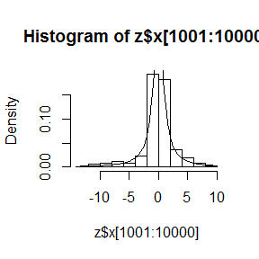

#### R code

```r
pi<-3.1415926
f<-function(x,u,lamada){
  t=lamada/(pi*(lamada^2+(x-u)^2))
  return(t)
}
g<-function(n,sigma,x0,u,lamada){
  x<-NULL
  x[1]<-x0
  e=runif(n)
  k<-0
  for(i in 2:n){
    y<-rnorm(1,x[i-1],sigma)
    if(e[i]<=(f(y,u,lamada)/f(x[i-1],u,lamada))){
      x[i]<-y
    }
    else
    {
      x[i]<-x[i-1]
      k<-k+1
    }
  }
  return(list(x=x,k=k))
}
z=g(n=10000,sigma=0.5,x0=0,u=0,lamada=1)
p=z$k/9000
p
hist(z$x[1001:10000],freq=F)
curve(f(x,0,1),add=TRUE)
```

### question 9.6

Rao [220, Sec. 5g] presented an example on genetic linkage of 197 animals in four categories (also discussed in [67, 106, 171, 266]). The group sizes are (125,18,20,34). Assume that the probabilities of the corresponding multinomial distribution are
$$(\frac{1}{2}+\frac{\theta}{4}, \frac{1-\theta}{4}, \frac{1-\theta}{4},\frac{\theta}{4})$$
. Estimate the posterior distribution of $\theta$ given the observed sample, using one of the methods in this chapter.

#### idea:

we can get the posterior distribution of $\theta$ given $(x_1,x_2,x_3,x_4)=(125,18,20,34)$.

#### answer:

```
## [1] 0.6291286
```

#### R code

```r
f=function(t){
  if (t < 0 || t >= 1){
    y=0
  }
  else{
    y=(1/2+t/4)^125 * ((1-t)/4)^18 * ((1-t)/4)^20 * (t/4)^34
  }
  return(y)
}
t1=runif(1000)
t2=runif(1000,-0.25,0.25)
x <- numeric(1000)
x[1]=0.25
for (i in 2:1000) {
  z = x[i-1] + t2[i]
  k= f(z) / f(x[i-1])
  if (t1[i] <= k)
    x[i]=z
  else
    x[i]=x[i-1]
}
z=x[100:1000]
p=mean(z)
p
```

## Question Exercises 9.6 Exercises 11.4

## Answer

### question 9.6

Rao [220, Sec. 5g] presented an example on genetic linkage of 197 animals in four categories (also discussed in [67, 106, 171, 266]). The group sizes are (125,18,20,34). Assume that the probabilities of the corresponding multinomial distribution are
$$(\frac{1}{2}+\frac{\theta}{4}, \frac{1-\theta}{4}, \frac{1-\theta}{4},\frac{\theta}{4})$$
. Estimate the posterior distribution of $\theta$ given the observed sample, using one of the methods in this chapter.

#### answer:

[output not shown]

### question 11.4

Find the intersection points A(k) in $(0, \sqrt{k})$ of the curves
$$S_{k-1}(a)=p \left( t(k-1)>\sqrt{\frac{a^2(k-1)}{k-a^2}} \right)$$
and
$$S_{k}(a)=p \left( t(k)>\sqrt{\frac{a^2k}{k+1-a^2}} \right)$$
for $k = 4:25, 100, 500, 1000$, where t(k) is a Student t random variable with k degrees of freedom. (These intersection points determine the critical values for a t-test for scale-mixture errors proposed by Szekely [260].)

#### idea:

We can solve $f(a)=S_{k-1}(a)-S_{k}(a)=0$, given k.

#### answer:

```
##         kc         A
##  [1,]    4  1.492119
##  [2,]    5  1.533558
##  [3,]    6  1.562757
##  [4,]    7  1.584430
##  [5,]    8  1.601180
##  [6,]    9  1.614519
##  [7,]   10  1.625384
##  [8,]   11  1.634381
##  [9,]   12  1.642026
## [10,]   13  1.648547
## [11,]   14  1.654150
## [12,]   15  1.659097
## [13,]   16  1.663432
## [14,]   17  1.667283
## [15,]   18  1.670724
## [16,]   19  1.673817
## [17,]   20  1.676614
## [18,]   21  1.679154
## [19,]   22  1.681442
## [20,]   23  1.683575
## [21,]   24  1.685536
## [22,]   25  1.687343
## [23,]  100  1.720599
## [24,]  500 22.338308
## [25,] 1000 31.606961
```

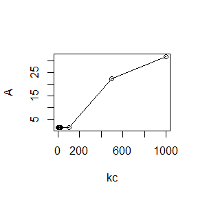

#### R code

```r
mys<-function(a,k){
  M=sqrt(a^2*k/(k+1-a^2))
  return(pt(M,df=k,lower.tail = FALSE))
}
myf<-function(a,k){
  mys(a=a,k=(k-1))-mys(a=a,k=k)
}
kc=c(4:25,100,500,1000)
A=rep(0,length(kc))
for(i in 1:length(kc)){
  A[i]=uniroot(myf,c(0.5,sqrt(kc[i]-1)),k=kc[i])$root
}
cbind(kc,A)
plot(kc,A,type="o")
```

## Question

Exercises 11.6 Exercises 2

## Answer

### question 11.6

Write a function to compute the cdf of the Cauchy distribution, which has density
$$\frac{1}{\theta\pi(1+[(x-\eta)/\theta]^2),-\infty<x<\infty}$$
, where $\theta>0$. Compare your results to the results from the R function pcauchy. (Also see the source code in pcauchy.c.)

#### idea:

First,we get the pdf of the Cauchy.Then we compare the result.

#### answer:

```
## [1] 0.5
```

```
## [1] 0.5
```

```
## [1] 0.25
```

```
## [1] 0.25
```

#### R code

```r
f<-function(t,m,n){
1/(m*3.141592653*(1+((t-n)/m)^2))
}

pdf<-function(x,m,n,lower.tail=TRUE){
 if(lower.tail) res<-integrate(f,lower = -Inf,upper = x,rel.tol=.Machine$double.eps^0.25,m=m,n=n)
 else res<-integrate(f,lower = x,upper = Inf,rel.tol=.Machine$double.eps^0.25,m=m,n=n)
  return(res$value)
}
pdf(x=0,m = 1,n = 0)
pcauchy(0,location = 0,scale = 1)
pdf(x=3,m = 2,n =1,lower.tail = F )
pcauchy(3,location = 1,scale = 2,lower.tail = F)
```

### question 2

- A-B-O blood type problem
- Let the three alleles be A, B, and O.

| Genotype | AA | BB | OO | AO | BO | AB | AA |
| --- | --- | --- | --- | --- | --- | --- | --- |
| Frequency | p2 | q2 | r2 | 2pr | 2qr | 2pq | 1 |
| Count | nAA | nBB | nOO | nAO | nBO | nAB | n |

#### idea:

First,we can get the complete data likelihood.Then we use the EM algorithm to calculation.

#### answer:

```
##           [,1]      [,2]
## [1,] 0.0000000 0.0000000
## [2,] 0.2000000 0.3500000
## [3,] 0.3162295 0.3089536
## [4,] 0.3260951 0.3098330
## [5,] 0.3271786 0.3103187
## [6,] 0.3273236 0.3104101
## [7,] 0.3273454 0.3104235
## [8,] 0.3273416 0.3104283
```

```
## [1] 280.5184 283.4459 283.8644 283.9259 283.9352 283.9365
```

#### R code

```r
library(nloptr)
f1 <- function(x,x1,n.A=28,n.B=24,nOO=41,nAB=70) {
  return(sum(x)-1)
}

f2 <- function(x,x1,n.A=28,n.B=24,nOO=41,nAB=70) {
  r1<-1-sum(x1)
  nAA<-n.A*x1[1]^2/(x1[1]^2+2*x1[1]*r1)
  nBB<-n.B*x1[2]^2/(x1[2]^2+2*x1[2]*r1)
  r<-1-sum(x)
  return(-2*nAA*log(x[1])-2*nBB*log(x[2])-2*nOO*log(r)-
           (n.A-nAA)*log(2*x[1]*r)-(n.B-nBB)*log(2*x[2]*r)-nAB*log(2*x[1]*x[2]))
}

opts <- list("algorithm"="NLOPT_LN_COBYLA",
             "xtol_rel"=1.0e-5)
mle<-c()
r<-matrix(0,1,2)
r<-rbind(r,c(0.2,0.35))
j<-2
while (sum(abs(r[j,]-r[j-1,]))>1e-5) {
res <- nloptr( x0=c(0.3,0.25),eval_f=f2,lb = c(0,0), ub = c(1,1), eval_g_ineq = f1, opts = opts,x1=r[j,],n.A=28,n.B=24,nOO=41,nAB=70 )
j<-j+1
r<-rbind(r,res$solution)
mle<-c(mle,f2(x=r[j,],x1=r[j-1,]))
}
r
mle
```

## Question

Exercises 3,Exercises 4 ???Exercises 5 in page 204 Exercises 3 in page 213??? Exercises 6 in page 214

## Answer

### Exercises 3

```
Use both for loops and lapply() to ???t linear models to the mtcars using the formulas stored in this list:
formulas <- list( mpg ~ disp,
mpg ~ I(1 / disp),
mpg ~ disp + wt,
mpg ~ I(1 / disp) + wt
)
```

#### idea:

We can use the formulas function to get the answer.

#### answer:

```
## [[1]]
##
## Call:
## lm(formula = f[[i]])
##
## Coefficients:
## (Intercept)         disp
##    29.59985     -0.04122
##
##
## [[2]]
##
## Call:
## lm(formula = f[[i]])
##
## Coefficients:
## (Intercept)    I(1/disp)
##       10.75      1557.67
##
##
## [[3]]
##
## Call:
## lm(formula = f[[i]])
##
## Coefficients:
## (Intercept)         disp           wt
##    34.96055     -0.01772     -3.35083
##
##
## [[4]]
##
## Call:
## lm(formula = f[[i]])
##
## Coefficients:
## (Intercept)    I(1/disp)           wt
##      19.024     1142.560       -1.798
```

```
## [[1]]
##
## Call:
## FUN(formula = X[[i]])
##
## Coefficients:
## (Intercept)         disp
##    29.59985     -0.04122
##
##
## [[2]]
##
## Call:
## FUN(formula = X[[i]])
##
## Coefficients:
## (Intercept)    I(1/disp)
##       10.75      1557.67
##
##
## [[3]]
##
## Call:
## FUN(formula = X[[i]])
##
## Coefficients:
## (Intercept)         disp           wt
##    34.96055     -0.01772     -3.35083
##
##
## [[4]]
##
## Call:
## FUN(formula = X[[i]])
##
## Coefficients:
## (Intercept)    I(1/disp)           wt
##      19.024     1142.560       -1.798
```

#### R code

```r
attach(mtcars)
f <- list( mpg ~ disp, mpg ~ I(1 / disp), mpg ~ disp + wt, mpg ~ I(1 / disp) + wt )
x <- vector("list", length(f))
for (i in seq_along(f)) { x[[i]] <-lm(f[[i]]) }
x
lapply(f,lm)
```

### Exercises 4

Fit the model mpg ~ disp to each of the bootstrap replicates of mtcars in the list below by using a for loop and lapply(). Can you do it without an anonymous function? bootstraps <- lapply(1:10, function(i) { rows <- sample(1:nrow(mtcars), rep = TRUE) mtcars[rows, ] })

#### answer:

```
##
## Call:
## lm(formula = mpg ~ disp, data = bootstraps[[i]])
##
## Coefficients:
## (Intercept)         disp
##    31.50377     -0.04868
##
##
## Call:
## lm(formula = mpg ~ disp, data = bootstraps[[i]])
##
## Coefficients:
## (Intercept)         disp
##    29.94543     -0.04091
##
##
## Call:
## lm(formula = mpg ~ disp, data = bootstraps[[i]])
##
## Coefficients:
## (Intercept)         disp
##    30.46321     -0.04683
##
##
## Call:
## lm(formula = mpg ~ disp, data = bootstraps[[i]])
##
## Coefficients:
## (Intercept)         disp
##    29.34209     -0.03929
##
##
## Call:
## lm(formula = mpg ~ disp, data = bootstraps[[i]])
##
## Coefficients:
## (Intercept)         disp
##    29.64297     -0.04092
##
```

[output cut: 24 more lines]

```
##
## Call:
## lm(formula = mpg ~ disp, data = bootstraps[[i]])
##
## Coefficients:
## (Intercept)         disp
##    28.23302     -0.03998
##
##
## Call:
## lm(formula = mpg ~ disp, data = bootstraps[[i]])
##
## Coefficients:
## (Intercept)         disp
##    29.23679     -0.03831
```

```
## [[1]]
##
## Call:
## FUN(formula = ..1, data = X[[i]])
##
## Coefficients:
## (Intercept)         disp
##    31.50377     -0.04868
##
##
## [[2]]
##
## Call:
## FUN(formula = ..1, data = X[[i]])
##
## Coefficients:
## (Intercept)         disp
##    29.94543     -0.04091
##
##
## [[3]]
##
## Call:
## FUN(formula = ..1, data = X[[i]])
##
## Coefficients:
## (Intercept)         disp
##    30.46321     -0.04683
##
##
## [[4]]
##
## Call:
## FUN(formula = ..1, data = X[[i]])
##
## Coefficients:
## (Intercept)         disp
##    29.34209     -0.03929
##
##
```

[output cut: 43 more lines]

```
## FUN(formula = ..1, data = X[[i]])
##
## Coefficients:
## (Intercept)         disp
##    28.23302     -0.03998
##
##
## [[10]]
##
## Call:
## FUN(formula = ..1, data = X[[i]])
##
## Coefficients:
## (Intercept)         disp
##    29.23679     -0.03831
```

#### R code

```r
bootstraps <- lapply(1:10, function(i) {
  rows <- sample(1:nrow(mtcars), rep = TRUE)
  mtcars[rows, ] })
for(i in seq_along(bootstraps)){
  print(lm(mpg~disp,data =bootstraps[[i]]))
}
lapply(bootstraps,lm,formula=mpg~disp)
```

### Exercises 5

For each model in the previous two exercises,extract $R^2$ using the function below. rsq <- function(mod) summary(mod)$r.squared

#### answer:

```
## [1] 0.7183433
## [1] 0.8596865
## [1] 0.7809306
## [1] 0.8838038
```

```
## [[1]]
## [1] 0.7183433
##
## [[2]]
## [1] 0.8596865
##
## [[3]]
## [1] 0.7809306
##
## [[4]]
## [1] 0.8838038
```

```
## [1] 0.7427474
## [1] 0.6125183
## [1] 0.7750816
## [1] 0.6701859
## [1] 0.8132919
## [1] 0.7328882
## [1] 0.696713
## [1] 0.7477347
## [1] 0.727212
## [1] 0.6404733
```

```
## [[1]]
## [1] 0.7427474
##
## [[2]]
## [1] 0.6125183
##
## [[3]]
## [1] 0.7750816
##
## [[4]]
## [1] 0.6701859
##
## [[5]]
## [1] 0.8132919
##
## [[6]]
## [1] 0.7328882
##
## [[7]]
## [1] 0.696713
##
## [[8]]
## [1] 0.7477347
##
## [[9]]
## [1] 0.727212
##
## [[10]]
## [1] 0.6404733
```

#### R code

```r
rsq <- function(mod) summary.lm(mod)$r.squared
for (i in seq_along(f)) {
 print( rsq(lm(f[[i]])))
  }
lapply(lapply(f,lm),rsq)
for(i in seq_along(bootstraps)){
  print(rsq(lm(mpg~disp,data =bootstraps[[i]])))
}
lapply(lapply(bootstraps,lm,f=mpg~disp),rsq)
```

### Exercises 3

The following code simulates the performance of a t-test for non-normal data. Use sapply() and an anonymous function to extract the p-value from every trial. trials <- replicate( 100, t.test(rpois(10, 10), rpois(7, 10)), simplify = FALSE ) Extra challenge: get rid of the anonymous function by using [[ directly.

#### idea:

We can use the anonymous function to get the answer.

#### answer:

```
##   [1] 0.32588029 0.34318950 0.95440191 0.98467801 0.15997333 0.11261316
##   [7] 0.05714928 0.52963027 0.05709930 0.08739680 0.03401028 0.28901313
##  [13] 0.56328900 0.68177763 0.83426320 0.23411688 0.94979747 0.09495784
##  [19] 0.53343527 0.29639097 0.18235694 0.87227048 0.09722528 0.95197390
##  [25] 0.88832754 0.07965729 0.55334731 0.82385057 0.21337226 0.81638343
##  [31] 0.22649417 0.25472380 0.52020952 0.86613365 0.62054749 0.46789612
##  [37] 0.17456146 0.32807523 0.97580067 0.98256490 0.42526504 0.51005864
##  [43] 0.50411381 0.50934348 0.64431949 0.49192279 0.95686848 0.22387176
##  [49] 0.34007946 0.73223185 0.74886418 0.27884850 0.16378589 0.71179551
##  [55] 0.05692813 0.07553506 0.50139695 0.30831789 0.33613952 0.41237126
##  [61] 0.15928880 0.79557579 0.63505176 0.75417037 0.45307450 0.01533525
##  [67] 0.52286985 0.24583078 0.98962081 0.81533086 0.81087909 0.56800422
##  [73] 0.42539157 0.88137613 0.79628024 0.72164471 0.09967479 0.74877072
##  [79] 0.36314529 0.90914552 0.32149186 0.24457869 0.81035411 0.06147907
##  [85] 0.91768581 0.35268204 0.56871736 0.55402732 0.62030510 0.68275544
##  [91] 0.13481538 0.68280619 0.33640997 0.82298126 0.90695505 0.95609879
##  [97] 0.48291741 0.87600679 0.54578553 0.43665539
```

#### R code

```r
trials <- replicate( 100, t.test(rpois(10, 10), rpois(7, 10)), simplify = FALSE )
p_value<-function(mod) mod$p.value
sapply(trials, p_value)
```

### Exercises 6

Implement a combination of Map() and vapply() to create an lapply() variant that iterates in parallel over all of its inputs and stores its outputs in a vector (or a matrix). What arguments should the function take?

#### answer:

```
## [1] 1.571429 3.555556
```

```
##      [,1] [,2]
## [1,]    1    3
## [2,]    1    3
## [3,]    2    4
## [4,]    2    4
## [5,]    2    4
```

#### R code

```r
x1=c(rep(1,3),rep(2,4))
x2=c(rep(3,4),rep(4,5))
x=list(x1,x2)
lapplyf=function(f,x){
  t=Map(f,x)
   n<-length(t[[1]])
   y=vapply(t,as.vector,numeric(n))
   return(y)
}
lapplyf(mean,x)
lapplyf(quantile,x)
```

## Question

exercise 4 exercise 5

## Answer

### Exercises 4

Make a faster version of chisq.test() that only computes the chi-square test statistic when the input is two numeric vectors with no missing values. You can try simplifying chisq.test() or by coding from the mathematical deffition (http://en. wikipedia.org/wiki/Pearson%27s_chi-squared_test).

#### answer:

```
##
##  Pearson's Chi-squared test
##
## data:  a and b
## X-squared = 11.531
```

```
##
##  Pearson's Chi-squared test
##
## data:  rbind(a, b)
## X-squared = 11.531, df = 2, p-value = 0.003134
```

```
## Unit: microseconds
##  expr    min      lq     mean   median      uq     max neval
##    t1 68.561  75.131 104.5053 113.3115 116.185 219.233   100
##    t2 98.943 108.590 149.6573 161.7565 164.219 250.435   100
```

#### R code

```r
library("microbenchmark")
my.chisq.test<-function(x,y){
if(!is.vector(x) && !is.vector(y))
stop("at least one of 'x' and 'y' is not a vector")
if(typeof(x)=="character" || typeof(y)=="character")
stop("at least one of 'x' and 'y' is not a numeric vector")
if(any(x<0) || anyNA(x))
stop("all entries of 'x' must be nonnegative and finite")
if(any(y<0) || anyNA(y))
stop("all entries of 'y' must be nonnegative and finite")
if((n<-sum(x))==0)
stop("at least one entry of 'x' must be positive")
if((n<-sum(x))==0)
stop("at least one entry of 'x' must be positive")
if(length(x)!=length(y))
stop("'x' and 'y' must have the same length")
DNAME<-paste(deparse(substitute(x)),"and",deparse(substitute(y)))
METHOD<-"Pearson's Chi-squared test"
x<-rbind(x,y)
nr<-as.integer(nrow(x));nc<-as.integer(ncol(x))
sr<-rowSums(x);sc<-colSums(x);n<-sum(x)
E<-outer(sr,sc,"*")/n
STATISTIC<-sum((x - E)^2/E)
names(STATISTIC)<-"X-squared"
structure(list(statistic=STATISTIC,method=METHOD,data.name=DNAME),class="htest")
}
a<-c(365,435,527);b<-c(231,389,453)
my.chisq.test(a,b)
chisq.test(rbind(a,b))
microbenchmark(t1=my.chisq.test(a,b),t2=chisq.test(rbind(a,b)))
```

### Exercises 5

Can you make a faster version of table() for the case of an input of two integer vectors with no missing values? Can you use it to speed up your chi-square test?

#### answer:

```
##    b
## a   1 2 3 4 5
##   1 2 0 0 0 0
##   2 0 1 0 0 0
##   3 0 0 1 0 0
##   4 0 0 0 1 0
##   5 0 0 0 0 1
```

```
##    b
## a   1 2 3 4 5
##   1 2 0 0 0 0
##   2 0 1 0 0 0
##   3 0 0 1 0 0
##   4 0 0 0 1 0
##   5 0 0 0 0 1
```

```
## Unit: microseconds
##  expr     min       lq     mean   median       uq     max neval
##    t1 185.978 192.9575 235.5601 197.8840 237.9125 456.529   100
##    t2 201.990 208.5590 259.2200 216.1535 276.2990 685.615   100
```

#### R code

```r
my.table<-function(...,dnn = list.names(...),deparse.level = 1){
    list.names <- function(...) {
        l <- as.list(substitute(list(...)))[-1L]
        nm <- names(l)
        fixup <- if (is.null(nm))
            seq_along(l)
        else nm == ""
        dep <- vapply(l[fixup], function(x) switch(deparse.level +
            1, "", if (is.symbol(x)) as.character(x) else "",
            deparse(x, nlines = 1)[1L]), "")
        if (is.null(nm))
            dep
        else {
            nm[fixup] <- dep
            nm
        }
    }
    args <- list(...)
    if (!length(args))
        stop("nothing to tabulate")
    if (length(args) == 1L && is.list(args[[1L]])) {
        args <- args[[1L]]
        if (length(dnn) != length(args))
            dnn <- if (!is.null(argn <- names(args)))
                argn
            else paste(dnn[1L], seq_along(args), sep = ".")
    }
    bin <- 0L
    lens <- NULL
    dims <- integer()
    pd <- 1L
    dn <- NULL
    for (a in args) {
        if (is.null(lens))
            lens <- length(a)
        else if (length(a) != lens)
            stop("all arguments must have the same length")
        fact.a <- is.factor(a)
        if (!fact.a) {
            a0 <- a
            a <- factor(a)
        }
        ll <- levels(a)
        a <- as.integer(a)
        nl <- length(ll)
        dims <- c(dims, nl)
        dn <- c(dn, list(ll))
        bin <- bin + pd * (a - 1L)
        pd <- pd * nl
    }
    names(dn) <- dnn
    bin <- bin[!is.na(bin)]
    if (length(bin))
        bin <- bin + 1L
    y <- array(tabulate(bin, pd), dims, dimnames = dn)
    class(y) <- "table"
    y
}
a=b=c(1,seq(1,5))
my.table(a,b)
table(a,b)
microbenchmark(t1=my.table(a,b),t2=table(a,b))
```